# Mathematische Statistik I Übung 13

Sven Bergmann

## Aufgabe 1

1. Bestimmen Sie die Randverteilungen von $X$.
2. Seien $X_1, \ldots, X_n$ unabhängig, je mit derselben Verteilung wie $X$. Gegeben seien $\lambda_0\in(0,\infty)$ und $\mu_0\in(0,\infty)$. Schlagen Sie unter Verwendung der Methode von Bonferroni einen Test zum Testniveau $\alpha\in(0,\infty)$ für das Testproblem
   $$H:\lambda = \lambda_0 \text{ und } \mu =
   \mu_0, K: \lambda\neq\lambda_0 \text{ oder } \mu\neq\mu_0$$
   basierend auf Beobachtungen von $X_1, \ldots, X_n$ vor. Überprüfen Sie für $\lambda_0=1$, $\mu_0=2$, $n = 10$ und $\alpha = 0.05$ mittels Simulation wie gut der Test das Testniveau einhält.

```r
draw_x <- function(n, lambda, mu) {
  y <- rexp(n = n, rate = lambda)
  return(cbind(y, pmin(y, rexp(n = n, rate = mu))))
}
```

```r
x <- draw_x(n = 10, lambda = 1, mu = 2)
```

## Aufgabe 2

Zu bekannten gegebenen Werten $t_i$ wurden die in der nachfolgenden Tabelle festgehaltenen Beobachtungswerte $x_i$ von Zufallsvariablen $X_i$ erhalten.

| $t_i$ | 0 | 1 | 2 | 3 | 4 | 5 | 6 | 7 | 8 | 9 |
| --- | --- | --- | --- | --- | --- | --- | --- | --- | --- | --- |
| $x_i$ | 1 | 1 | 2 | 3 | 5 | 3 | 7 | 6 | 8 | 9 |

Es liege das Modell
$$X_i = a + bt_i +
Z_i, a, b \in\mathbb{R}$$
unbekannt, mit unabhängigen $\mathcal{N}(0, \sigma^2)$-verteilten Zufallsvariablen $Z_1, \ldots, Z_n$, je mit derselben unbekannten Varianz $\sigma^2 > 0$ zugrunde. Es sei $t_0 = 3.8$. Geben Sie ein Konfidenzintervall zum Konfidenzniveau $0.95$ für $a + bt_0$ an. —- Aus Beispiel 3.3:

```r
ci_simple_lin_reg <- function(x, y, gamma = 0.95, t_0 = NULL) {
  n <- length(x)
  y_bar <- mean(y)
  sigma_y_squared <- (1 / n) * sum((y - y_bar)^2)
  t <- (y - y_bar) / sqrt(sigma_y_squared)

  x_bar <- mean(x)
  alpha_hat <- x_bar

  x_t_bar <- mean(x * t)
  beta_hat <- x_t_bar

  sigma_hat_squared_alpha_hat_beta_hat <- mean(x^2) - x_bar^2 - x_t_bar^2

  res_list_with_t_0 <- list()

  sigma_y <- sd(y)
  a_hat <- alpha_hat - beta_hat * (y_bar / sigma_y)
  b_hat <- beta_hat / sigma_y
  sigma_hat_squared_a_hat_b_hat <- (1 / n) * sum(x - (a_hat - (b_hat * y)))^2

  if (length(t_0) != 0) {
    term_alpha_hat_beta_hat <- qt(df = n - 1, p = 1 - (gamma / 2)) * sqrt((sigma_hat_squared_alpha_hat_beta_hat / (n - 2)) * (1 + t_0^2))
    ci_lower_alpha_hat_beta_hat <- alpha_hat +
      beta_hat * t_0 - term_alpha_hat_beta_hat
    ci_upper_alpha_hat_beta_hat <- alpha_hat +
      beta_hat * t_0 +
      term_alpha_hat_beta_hat

    term_a_hat_b_hat <- qt(df = n - 2, p = 1 - (gamma / 2)) * sqrt((sigma_hat_squared_a_hat_b_hat / (n - 2)) * (1 + t_0^2))
    y_0 <- (t_0 * sigma_y) + y_bar
    ci_lower_a_hat_b_hat <- a_hat + b_hat * y_0 - term_a_hat_b_hat
    ci_upper_a_hat_b_hat <- a_hat + b_hat * y_0 + term_a_hat_b_hat

    res_list_with_t_0 <- list(ci_lower_alpha_hat_beta_hat = ci_lower_alpha_hat_beta_hat, ci_upper_alpha_hat_beta_hat = ci_upper_alpha_hat_beta_hat,
                              y_0 = y_0,
                              ci_lower_a_hat_b_hat = ci_lower_a_hat_b_hat, ci_upper_a_hat_b_hat = ci_upper_a_hat_b_hat)
  }

  res_list <- list(t = t,
                   alpha_hat = alpha_hat, beta_hat = beta_hat, sigma_hat_squared_alpha_hat_beta_hat = sigma_hat_squared_alpha_hat_beta_hat,
                   a_hat = a_hat, b_hat = b_hat, sigma_hat_squared_a_hat_b_hat = sigma_hat_squared_a_hat_b_hat)

  return(c(res_list, res_list_with_t_0))
}
```

Tausche die Namen wegen der Vorschrift für $X_i$.

```r
x <- c(1, 1, 2, 3, 5, 3, 7, 6, 8, 9)
y <- c(0, 1, 2, 3, 4, 5, 6, 7, 8, 9)
t_0 <- 3.8
gamma <- 0.95
aufgabe_2 <- ci_simple_lin_reg(x = x, y = y, gamma = gamma, t_0 = t_0)
```

Modell: $X_j = a + by_j + Z_i, a, b \in\mathbb{R}$.

Setze nun $\sigma_y^2 = \frac{1}{n}\sum\limits_{i=1}^{n}(y_i-\bar{y})^2$ mit $\bar{y}=\frac{1}{n}\sum\limits_{i=1}^{n}y_i$ und $t_j = \frac{y_j-\bar{y}}{\sigma_y}, j=1, \ldots, n$.

Dann sind die ML Schätzer:
$$\hat{\alpha}
= \bar{X}$$
$$\hat{\beta} =
\bar{Xy}$$
$$\hat{\sigma}^2 =
\bar{X^2} - \bar{X}^2 - \bar{Xy}^2$$

```r
cat('alpha_hat:', aufgabe_2$alpha_hat, ', beta_hat:', aufgabe_2$beta_hat, ', sigma_hat_squared_alpha_hat_beta_hat:', aufgabe_2$sigma_hat_squared_alpha_hat_beta_hat)
```

```
alpha_hat: 4.5 , beta_hat: 2.628573 , sigma_hat_squared_alpha_hat_beta_hat: 0.7406061
```

Der Konfidenzintervallschätzer für $\alpha + \beta t_0$ zum Konfidenzniveau $1-\gamma$ ist gegeben durch:
$$\left[\hat{\alpha} + \hat{\beta}t_0 -
c\sqrt{\frac{\hat{\sigma}^2}{n-2}(1+t_0^2)},
\hat{\alpha} + \hat{\beta}t_0 +
c\sqrt{\frac{\hat{\sigma}^2}{n-2}(1+t_0^2)}\right]$$

```r
cat('Der Konfidenzintervallschaetzer fuer alpha + beta*t_0 zum Konfidenzniveau 1-gamma:', 1 - gamma, 'ist: [', aufgabe_2$ci_lower_alpha_hat_beta_hat, ',', aufgabe_2$ci_upper_alpha_hat_beta_hat, '], mit einer Breite von', aufgabe_2$ci_upper_alpha_hat_beta_hat - aufgabe_2$ci_lower_alpha_hat_beta_hat)
```

```
Der Konfidenzintervallschaetzer fuer alpha + beta*t_0 zum Konfidenzniveau 1-gamma: 0.05 ist: [ 14.41149 , 14.56566 ], mit einer Breite von 0.1541721
```

Rücktransformation in $\hat{a}, \hat{b}$:

```r
cat('a_hat:', aufgabe_2$a_hat, ', b_hat:', aufgabe_2$b_hat, 'sigma_hat_squared_a_hat_b_hat:', aufgabe_2$sigma_hat_squared_a_hat_b_hat)
```

```
a_hat: 0.5931497 , b_hat: 0.868189 sigma_hat_squared_a_hat_b_hat: 610.5392
```

Das Konfidenzintervallschätzer für $a + b\cdot t_0$ zum Konfidenzniveau $1-\gamma$ ist gegeben durch:
$$\Bigg[\hat{a}+\hat{b}y_0 -
t_{n-2,1-\frac{\gamma}{2}}\sqrt{\frac{\hat{\sigma}^2}{n-2}\left(1+\frac{\left(y_0-\overline{y}\right)^2}{\sigma_y^2}\right)},$$
$$\hat{a}+\hat{b}y_0 +
t_{n-2,1-\frac{\gamma}{2}}\sqrt{\frac{\hat{\sigma}^2}{n-2}\left(1+\frac{\left(y_0-\overline{y}\right)^2}{\sigma_y^2}\right)}\Bigg]$$
mit
$$t_0 =
\frac{\left(y_0-\bar{y}\right)}{\sigma_y}$$
also
$$y_0 = (t_0\cdot\sigma_y)+\bar{y}$$

```r
cat('Der Konfidenzintervallschaetzer fuer a + b*t_0 zum Konfidenzniveau 1-gamma:', 1 - gamma, 'ist: [', aufgabe_2$ci_lower_a_hat_b_hat, ',', aufgabe_2$ci_upper_a_hat_b_hat, '], mit einer Breite von', aufgabe_2$ci_upper_a_hat_b_hat - aufgabe_2$ci_lower_a_hat_b_hat)
```

```
Der Konfidenzintervallschaetzer fuer a + b*t_0 zum Konfidenzniveau 1-gamma: 0.05 ist: [ 12.2676 , 16.70955 ], mit einer Breite von 4.441944
```

## Aufgabe 3

Die Resultate von gleichgenauen Messungen der Eindringtiefe $x_i$ eines Projektils in ein Hindernis bei verschiedenen einstellbaren Werten seiner spezifischen Energie $v_i$ (d.h. Energie pro Einheitsfläche des Hindernisses) sind in der nachfolgenden Tabelle angegeben.

| $v_i$ | 41 | 50 | 81 | 104 | 120 | 139 | 154 | 180 | 208 | 241 | 250 | 269 | 301 |
| --- | --- | --- | --- | --- | --- | --- | --- | --- | --- | --- | --- | --- | --- |
| $x_i$ | 4 | 8 | 10 | 14 | 16 | 20 | 19 | 23 | 26 | 30 | 31 | 36 | 37 |

Nehmen Sie an, dass die beobachteten Eindringtiefen ermittelte Werte von unabhängigen Zufallsvariablen $X_i \sim \mathcal{N}(a + bv_i, \sigma^2)$ mit unbekannten Parametern $a, b \in\mathbb{R}$ und $\sigma^2 > 0$ sind. Erstellen Sie eine grafische Darstellung des Konfidenzgürtels zum Konfidenzniveau 0.95 für $a + bv$, $v \in\mathbb{R}$.

Tausche die Namen wegen der Vorschrift für $X_i$.

```r
x <- c(4, 8, 10, 14, 16, 20, 19, 23, 26, 30, 31, 36, 37)
y <- c(41, 50, 81, 104, 120, 139, 154, 180, 208, 241, 250, 269, 301)
gamma <- 0.95
```

Aus Aufgabe 2:

```r
aufgabe_3 <- ci_simple_lin_reg(x = x, y = y, gamma = gamma)
```

Grenzen für Konfidenzgürtelschätzer:
$$\hat{\alpha}+\hat{\beta}t \pm \sqrt{\frac{2}{n-2}
F_{2, n-2; 1-\gamma} \hat{\sigma}^2 \left(1+t^2\right)},
t\in\mathbb{R}$$

```r
conf_guertel_schaetzer <- function(alpha_hat, beta_hat, t, n, gamma, sigma_hat_squared, lower) {
  term <- sqrt((2 / (n - 2)) *
                 qf(p = 1 - gamma, df1 = 2, df2 = n - 2) *
                 sigma_hat_squared *
                 (1 + t^2))
  return(ifelse(lower,
                alpha_hat + beta_hat * t - term,
                alpha_hat + beta_hat * t + term))
}
```

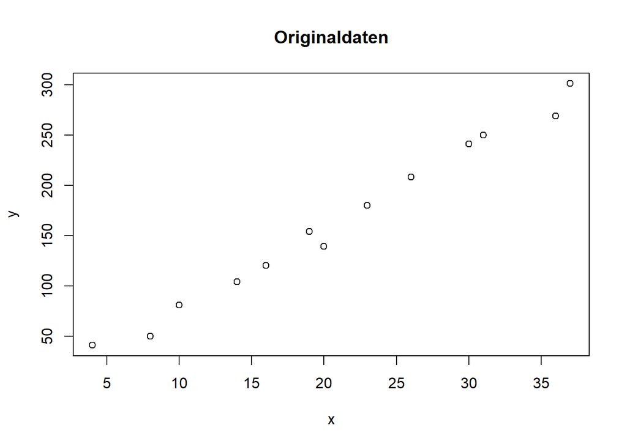

```r
plot(x, y, main = 'Originaldaten')
```

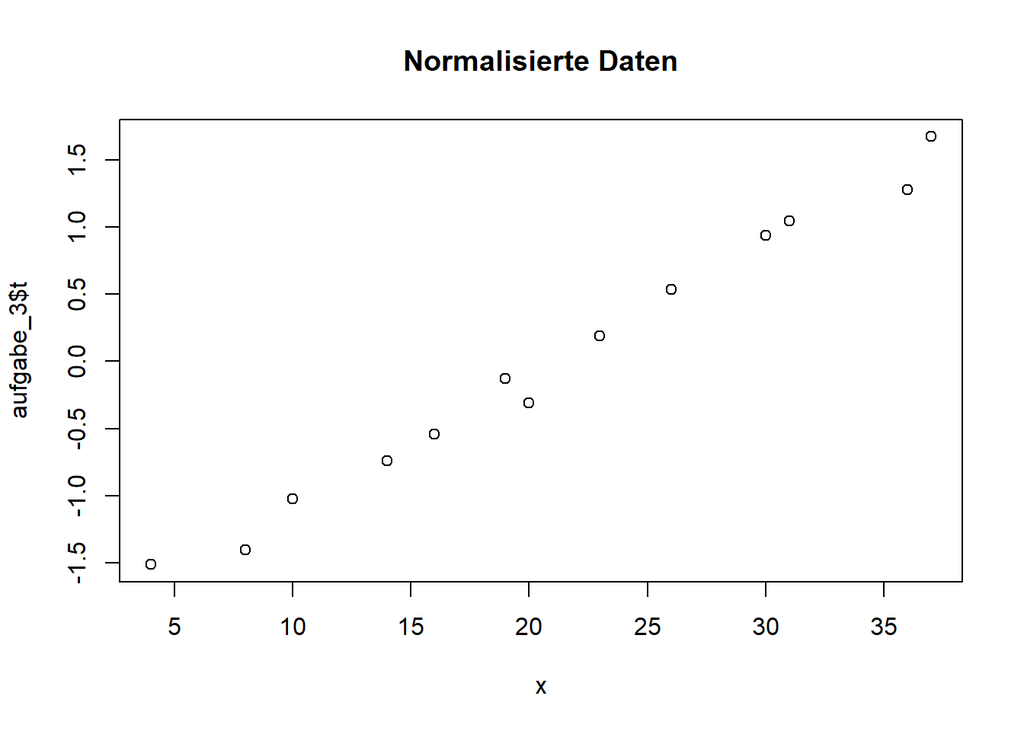

```r
plot(x, aufgabe_3$t, main = 'Normalisierte Daten')
```

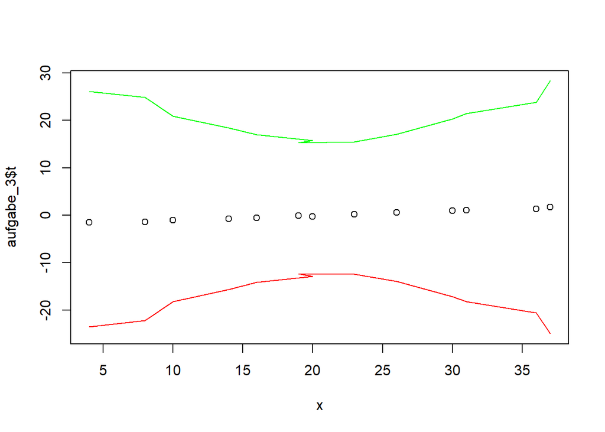

```r
schaetzer_upper_a_hat_b_hat <- sapply(X = aufgabe_3$t, FUN = function(x) conf_guertel_schaetzer(alpha_hat = aufgabe_3$a_hat, beta_hat = aufgabe_3$b_hat, t = x, n = length(aufgabe_3$t), gamma = gamma, sigma_hat_squared = aufgabe_3$sigma_hat_squared_a_hat_b_hat, lower = FALSE))
schaetzer_lower_a_hat_b_hat <- sapply(X = aufgabe_3$t, FUN = function(x) conf_guertel_schaetzer(alpha_hat = aufgabe_3$a_hat, beta_hat = aufgabe_3$b_hat, t = x, n = length(aufgabe_3$t), gamma = gamma, sigma_hat_squared = aufgabe_3$sigma_hat_squared_a_hat_b_hat, lower = TRUE))
plot(x, aufgabe_3$t, xlim = c(min(x), max(x)), ylim = c(min(schaetzer_lower_a_hat_b_hat), max(schaetzer_upper_a_hat_b_hat)))
lines(x, schaetzer_upper_a_hat_b_hat, col = 'green')
lines(x, schaetzer_lower_a_hat_b_hat, col = 'red')
```

[output not shown]